# Data Workflow Replication Project

Nathan Storey

5/13/2020

#Create Analytic Dataset {-} ##Import and Prepare Full Dataset {-} The dataset contains student-level data from survey responses regarding math attitudes, pre- and post-test standardized math scores, demographic data, grand-mean centered versions of the demographic data, and a weight variable due to propensity score matching.

```r
#Load libraries
library(tidyverse)
library(readxl)
library(stargazer)
library(knitr)
library(kableExtra)
library(broom)

#Import dataset from Excel
setwd("~/GitHub/Storey_final_workflow/data")
Fenton <- read_excel("Fenton all data.xlsx")

#Keep variables: Treatment, Q2, ID, Q3_1, Q3_2, Q3_4, Q3_5, Q3_6, Q3_7, Q3_8
#Keep Q3_1_Post, Q2_Post, Q3_2_Post, Q3_4_Post, Q3_5_Post, Q3_6_Post, Q3_7_Post, Q3_8_Post,
#Keep TestRitScore, Post_RIT_Score, Teacher1, Teacher2, Teacher3, Teacher4, Gender, non_white, Weight
#Keep centered_pretest, centered_gender, centered_non_white, total_lessons_complete, class_score_percent
#Rename to lowercase titles

Fenton <- select(Fenton, "Treatment", "Q3_1", "Q3_2", "Q3_3",
                 "Q3_4", "Q3_5", "Q3_6", "Q3_7", "Q3_8", "Q3_1_Post", "Q3_2_Post",
                 "Q3_3_Post", "Q3_4_Post", "Q3_5_Post", "Q3_6_Post", "Q3_7_Post",
                 "Q3_8_Post", "TestRITScore", "Post_RIT_Score", "Teacher1", "Teacher2",
                 "Teacher3", "Teacher4", "Gender", "non_white", "Weight",
                 "centered_pretest", "centered_gender", "centered_non_white",
                 "total_lessons_complete", "class_score_percent") %>%
  rename(treatment = "Treatment", female = "Gender", postRIT = "Post_RIT_Score",
         PreRIT = "TestRITScore", teacher1="Teacher1", teacher2 = "Teacher2",
         teacher3 = "Teacher3", teacher4 = "Teacher4")


#Create summary/mean versions of survey wrap up variables?
#Category1: Math self-efficacy--Q1-3, Q1-3_Post
#Category2: Math enjoyment--Q5&6, 5&6_Post
#Category3: Math effort--Q4&8, 4&8_Post
#Category4: Math answers make sense--Q7, 7_Post
Fenton <- mutate(Fenton, selfefficacy_pre = (Q3_1 + Q3_2 + Q3_3)/3)
Fenton <- mutate(Fenton, enjoyment_pre = (Q3_5+Q3_6)/2)
Fenton <- mutate(Fenton, effort_pre = (Q3_4 + Q3_8)/2)
Fenton <- mutate(Fenton, answersense_pre = Q3_7)
Fenton <- mutate(Fenton, selfefficacy_post = (Q3_1_Post + Q3_2_Post + Q3_3_Post)/3)
Fenton <- mutate(Fenton, enjoyment_post = (Q3_5_Post + Q3_6_Post)/2)
Fenton <- mutate(Fenton, effort_post = (Q3_4_Post + Q3_8_Post)/2)
Fenton <- mutate(Fenton, answersense_post = Q3_7_Post)
```

#Descriptive Analysis {-} ##Replicate Table 1 {-} Below is a screenshot of Table 1 from Cook, et al., 2019.

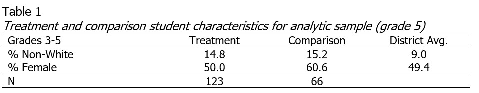

##Examine Table 1 {-} The researchers note that the comparison group had a higher percentage of females than the treatment group and the district. In addition, it is apparent that the treatment and control groups differ, particularly in the percentage of females in each. This led the team to use propensity score matching for their analysis.

##Create Table 1 {-} Below is my replica of Table 1: Treatment and comparison student characteristics for analytic sample

```r
df <- filter(Fenton, !is.na(treatment)) %>%
  group_by(treatment) %>%
  summarize(
    `% Non-White` = mean(non_white, na.rm=TRUE)*100,
    `% Female` = mean(female, na.rm=TRUE)*100,
    N=n()
  ) %>% arrange(desc(treatment)) %>% select(-treatment) %>% t %>% as.data.frame

colnames(df) <-c("Treatment", "Comparison")


df$`District Avg.` <- c("9.0", "49.4", "")

knitr::kable(df, "html", booktabs = T, caption = "Treatment and comparison student characteristics for analytic sample (grades 3-5)") %>%
               kable_styling(latex_options = c("striped", "hold_position"))
```

Treatment and comparison student characteristics for analytic sample (grades 3-5)

|  | Treatment | Comparison | District Avg. |
| --- | --- | --- | --- |
| % Non-White | 14.0625 | 16.17647 | 9.0 |
| % Female | 50.0000 | 61.76471 | 49.4 |
| N | 139.0000 | 68.00000 |  |

##Replicate Model {-} Below is the model used in this study.
$$\mathbf Final MAP Score_i = \\ Intercept + ClassPace~enrollment_i + Initial~MAP~score_i +\sum(teacher)_i + gender_i + e_i$$

##Replicate Table 5 {-} Below is a screenshot of Table 5.

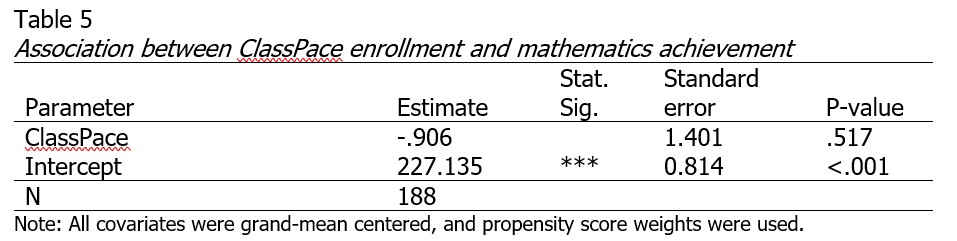

##Examine Table 5 {-} The table does not depict the results from all variables in the model, above. The table includes a column showing significance, though it does not specify what thresholds are used for different numbers of asterisks. The only variable presented is the ClassPace enrollment variable, as well as the Intercept. The result for enrollment in ClassPace is negative, but not statistically significant. The covariates used in the model are grand-mean centered, and propensity scores were used. N is 188.

##Create Table 5 {-} Below is my replication of Table 5: Association between ClassPace enrollment and mathematics achievement.

```r
library(knitr)
library(kableExtra)
library(broom)
library(stargazer)

model <- lm(postRIT ~ treatment+centered_pretest+teacher1+teacher2+teacher3+teacher4+centered_gender, weights=Weight, data=Fenton)

#stargazer(model, title="Regression Results", align=TRUE, covariate.labels=c("Intercept","ClassPace Privileges", "Pretest","Teacher1","Teacher2","Teacher3", "Gender"), omit.stat=c("LL","ser","f"), no.space=TRUE, na.rm=TRUE)


tidy(model)
```

| term | estimate | std.error | statistic | p.value |
| --- | --- | --- | --- | --- |
| (Intercept) | 226.7630807 | 1.1425335 | 198.47390391 | 1.068804e-213 |
| treatment | -0.9055832 | 1.3942260 | -0.64952398 | 5.168232e-01 |
| centered_pretest | 0.9613557 | 0.0345993 | 27.78541091 | 3.376662e-67 |
| teacher1 | 1.3545039 | 1.2407804 | 1.09165478 | 2.764358e-01 |
| teacher2 | 0.3748707 | 1.4852630 | 0.25239349 | 8.010233e-01 |
| teacher3 | 0.1084287 | 1.5511604 | 0.06990166 | 9.443491e-01 |
| centered_gender | -1.7607712 | 0.8521482 | -2.06627352 | 4.022685e-02 |

```r
#look up library(broom)--take objects to make df
#OR look up stargazer--option to not display certain covariates?
#N should be available through summary, stargazer lets you put the N
```

Note: All covariates were grand-mean centered, and propensity score weights were used.

##Replicate Table 7 {-} Below is a screenshot of Table 7

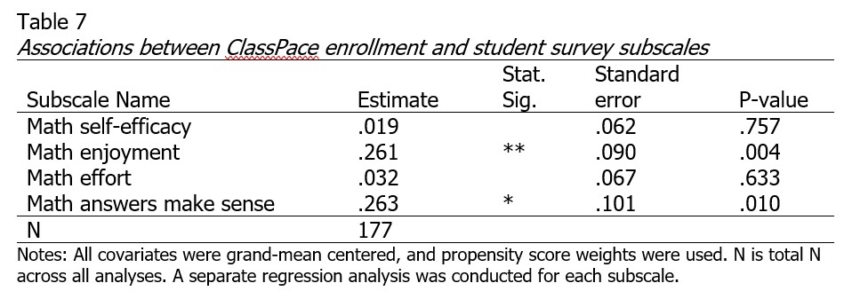

##Examine Table 7 The table does not depict the results from all variables in the model, above. The table includes a column showing significance, though it does not specify what thresholds are used for different numbers of asterisks. All covariates were grand-mean centered, and propensity score weights were used.

#Create Table 7: Associations between ClassPace enrollment and student survey statistics

```r
library(dplyr)

m1 <- lm(selfefficacy_post ~ treatment+selfefficacy_pre+teacher1+teacher2+teacher3+teacher4+centered_gender, weights=Weight, data=Fenton)
m2 <- lm(enjoyment_post ~ treatment+enjoyment_pre+teacher1+teacher2+teacher3+teacher4+centered_gender, weights=Weight, data=Fenton)
m3 <- lm(effort_post ~ treatment+effort_pre+teacher1+teacher2+teacher3+teacher4+centered_gender, weights=Weight, data=Fenton)
m4 <- lm(answersense_post ~ treatment+answersense_pre+teacher1+teacher2+teacher3+teacher4+centered_gender, weights=Weight, data=Fenton)

suppressWarnings(stargazer(m1, m2, m3, m4, type="text",
          dep.var.labels=c("Survey Subscales"),
          omit=c("Intercept", "teacher1", "teacher2", "teacher3", "teacher4", "centered_gender", "Constant"),
          covariate.labels=c("Intercept", "Math Self-efficacy","Math enjoyment", "Math effort","Math answers make sense"), nobs = TRUE))
```

[output not shown]

###Alternate Replication

```r
library(dplyr)

m1 <- lm(selfefficacy_post ~ treatment+selfefficacy_pre+teacher1+teacher2+teacher3+teacher4+centered_gender, weights=Weight, data=Fenton)
m2 <- lm(enjoyment_post ~ treatment+enjoyment_pre+teacher1+teacher2+teacher3+teacher4+centered_gender, weights=Weight, data=Fenton)
m3 <- lm(effort_post ~ treatment+effort_pre+teacher1+teacher2+teacher3+teacher4+centered_gender, weights=Weight, data=Fenton)
m4 <- lm(answersense_post ~ treatment+answersense_pre+teacher1+teacher2+teacher3+teacher4+centered_gender, weights=Weight, data=Fenton)

tidy(m1)
```

| term | estimate | std.error | statistic | p.value |
| --- | --- | --- | --- | --- |
| (Intercept) | 0.70221649 | 0.18283760 | 3.8406569 | 1.729562e-04 |
| treatment | 0.09624001 | 0.09968310 | 0.9654596 | 3.356861e-01 |
| selfefficacy_pre | 0.74327231 | 0.05692012 | 13.0581648 | 1.951129e-27 |
| teacher1 | 0.12163626 | 0.08684703 | 1.4005806 | 1.631621e-01 |
| teacher2 | 0.10174056 | 0.10668896 | 0.9536184 | 3.416308e-01 |
| teacher3 | 0.26318771 | 0.10888166 | 2.4171905 | 1.669818e-02 |
| centered_gender | -0.03406183 | 0.06163359 | -0.5526505 | 5.812287e-01 |

```r
tidy(m2)
```

| term | estimate | std.error | statistic | p.value |
| --- | --- | --- | --- | --- |
| (Intercept) | 0.924486030 | 0.19191974 | 4.81704496 | 3.208041e-06 |
| treatment | 0.225437384 | 0.15761374 | 1.43031556 | 1.544619e-01 |
| enjoyment_pre | 0.612494951 | 0.05792788 | 10.57340491 | 2.121546e-20 |
| teacher1 | 0.340387339 | 0.13727452 | 2.47961046 | 1.412698e-02 |
| teacher2 | 0.329883361 | 0.16763619 | 1.96785288 | 5.071156e-02 |
| teacher3 | 0.034140599 | 0.17004173 | 0.20077777 | 8.411124e-01 |
| centered_gender | 0.007097741 | 0.09506672 | 0.07466063 | 9.405725e-01 |

```r
tidy(m3)
```

| term | estimate | std.error | statistic | p.value |
| --- | --- | --- | --- | --- |
| (Intercept) | 1.6824374 | 0.21614224 | 7.7839359 | 6.550148e-13 |
| treatment | 0.1079828 | 0.10929905 | 0.9879573 | 3.245776e-01 |
| effort_pre | 0.4939990 | 0.05585247 | 8.8447113 | 1.140776e-15 |
| teacher1 | 0.1420130 | 0.09618216 | 1.4765004 | 1.416596e-01 |
| teacher2 | 0.1824478 | 0.11754977 | 1.5520897 | 1.225004e-01 |
| teacher3 | 0.1980970 | 0.12018886 | 1.6482145 | 1.011556e-01 |
| centered_gender | 0.1382441 | 0.06837474 | 2.0218590 | 4.475898e-02 |

```r
tidy(m4)
```

| term | estimate | std.error | statistic | p.value |
| --- | --- | --- | --- | --- |
| (Intercept) | 1.90879395 | 0.25742510 | 7.4149489 | 5.498440e-12 |
| treatment | 0.49582761 | 0.16275058 | 3.0465490 | 2.684286e-03 |
| answersense_pre | 0.23171140 | 0.07152782 | 3.2394582 | 1.440529e-03 |
| teacher1 | 0.08542018 | 0.14255409 | 0.5992124 | 5.498290e-01 |
| teacher2 | 0.22793303 | 0.17491941 | 1.3030745 | 1.943115e-01 |
| teacher3 | 0.53551040 | 0.17842758 | 3.0012760 | 3.093545e-03 |
| centered_gender | -0.01202851 | 0.09983313 | -0.1204861 | 9.042403e-01 |

##Replicate Figure 3

###Figure 3 Below is a screenshot of Figure 3: Regression-adjusted means for student survey subscales

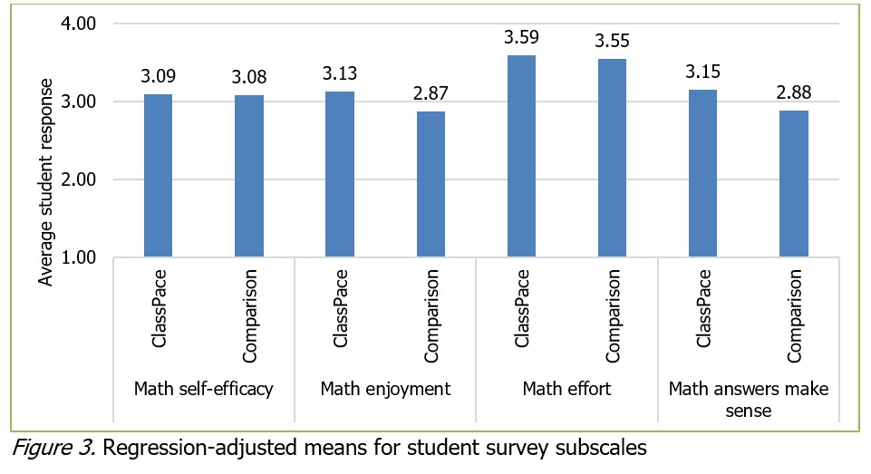

##Examine Figure 3 From the mean results, we see that Math effort has the highest overall means for both treatment(ClassPace) and control (Comparison) groups. Each subscale reports both treatment and control means.

##Recreate Figure 3 Regression-adjusted means for student survey subscales

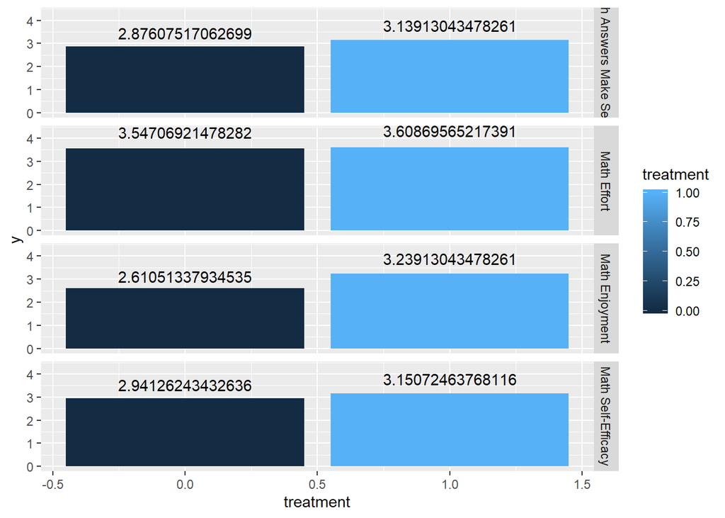

```r
#library(mice)
#md.pattern(select(Fenton, teacher1, selfefficacy_post, selfefficacy_pre, teacher2, teacher3, teacher4, centered_gender, Weight))

surveyFenton <- select(Fenton, teacher1, treatment, selfefficacy_post, selfefficacy_pre, teacher2, teacher3, teacher4, centered_gender, Weight, enjoyment_pre, enjoyment_post, effort_pre, effort_post, answersense_pre, answersense_post) %>%
                       filter(complete.cases(.))

m1 <- lm(selfefficacy_post ~ treatment+selfefficacy_pre+teacher1+teacher2+teacher3+teacher4+centered_gender, weights=Weight, data=surveyFenton)
m2 <- lm(enjoyment_post ~ treatment+enjoyment_pre+teacher1+teacher2+teacher3+teacher4+centered_gender, weights=Weight, data=surveyFenton)
m3 <- lm(effort_post ~ treatment+effort_pre+teacher1+teacher2+teacher3+teacher4+centered_gender, weights=Weight, data=surveyFenton)
m4 <- lm(answersense_post ~ treatment+answersense_pre+teacher1+teacher2+teacher3+teacher4+centered_gender, weights=Weight, data=surveyFenton)

surveyFenton$selfefficacy_post_fit <- predict(m1)
surveyFenton$enjoyment_post_fit <- predict(m2)
surveyFenton$effort_post_fit <- predict(m3)
surveyFenton$answersense_post_fit <- predict(m4)

surveyFenton <- surveyFenton %>%
  group_by(treatment) %>%
  summarize(
    `Math Self-Efficacy` = mean(selfefficacy_post_fit, na.rm=TRUE),
    `Math Enjoyment` = mean(enjoyment_post_fit, na.rm=TRUE),
    `Math Effort` = mean(effort_post_fit, na.rm=TRUE),
    `Math Answers Make Sense` = mean(answersense_post_fit, na.rm=TRUE),
  ) %>%
  pivot_longer(
    c("Math Self-Efficacy", "Math Enjoyment", "Math Effort", "Math Answers Make Sense"),
    names_to = "facet",
    values_to = "y"
  )

ggplot(surveyFenton) +
  geom_col(aes(x=treatment, y=y, fill=treatment))+
  geom_text(aes(x=treatment, y=y, label=y),
            position = position_stack(vjust = 1.2))+
  facet_grid(vars(facet))
```